# Diamonds quality

In this data challenge we explore the qualities of diamonds and their association with price using the `ggplot2::diamonds` dataset:

1. First of all, observe that low quality diamonds (with respect to cut, color and clarity) are more expensive.
2. Using models, find an explanation and solve the apparent paradox.

Recall that:

- best cut is Ideal, worst is Fair
- best color is D, worst is J
- best clarity is IF, worst is I1

```r
library(tidyverse)
library(ggplot2)
library(broom)
```

### Price of diamonds in relation to their quality

Since quality in the diamonds dataset is captured by three categorical variables (`cut`, `color`, and `clarity`), we create a boxplot on a logarithmic price scale to normalize the right-skewed distribution, handle the heavy tail of high-priced diamonds, and clearly display medians and means (red diamonds):

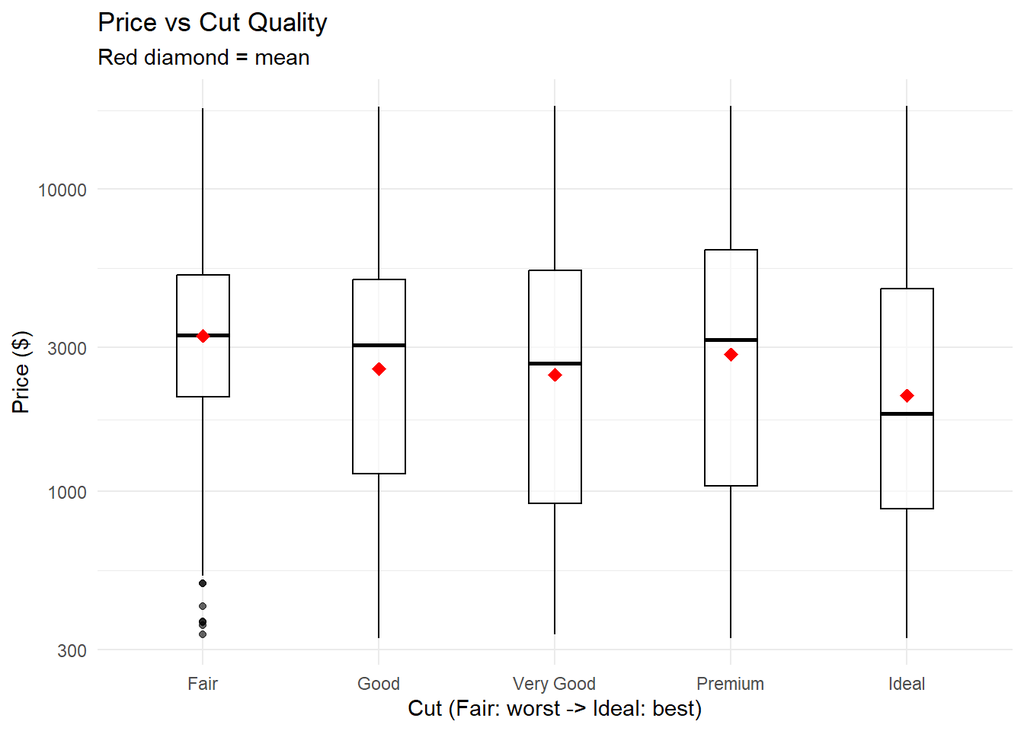

```r
# 1. Price vs Cut (Fair is worst, Ideal is best)
ggplot(diamonds, aes(x = cut, y = price)) +
  geom_boxplot(alpha = 0.6, fill = "white", color = "black", width = 0.3) +
  stat_summary(fun = mean, geom = "point", shape = 18, size = 3, color = "red") +
  scale_y_log10() +
  labs(
    title = "Price vs Cut Quality",
    subtitle = "Red diamond = mean",
    x = "Cut (Fair: worst -> Ideal: best)",
    y = "Price ($)"
  ) +
  theme_minimal()
```

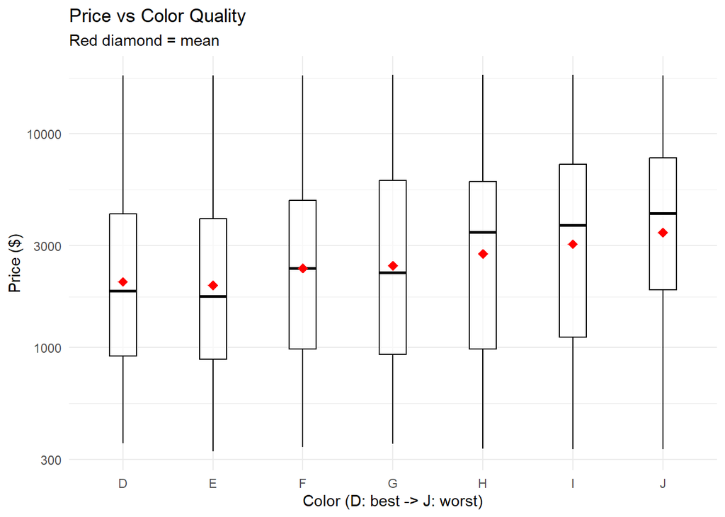

```r
# 2. Price vs Color (D is best, J is worst)
ggplot(diamonds, aes(x = color, y = price)) +
  geom_boxplot(alpha = 0.6, fill = "white", color = "black", width = 0.3) +
  stat_summary(fun = mean, geom = "point", shape = 18, size = 3, color = "red") +
  scale_y_log10() +
  labs(
    title = "Price vs Color Quality",
    subtitle = "Red diamond = mean",
    x = "Color (D: best -> J: worst)",
    y = "Price ($)"
  ) +
  theme_minimal()
```

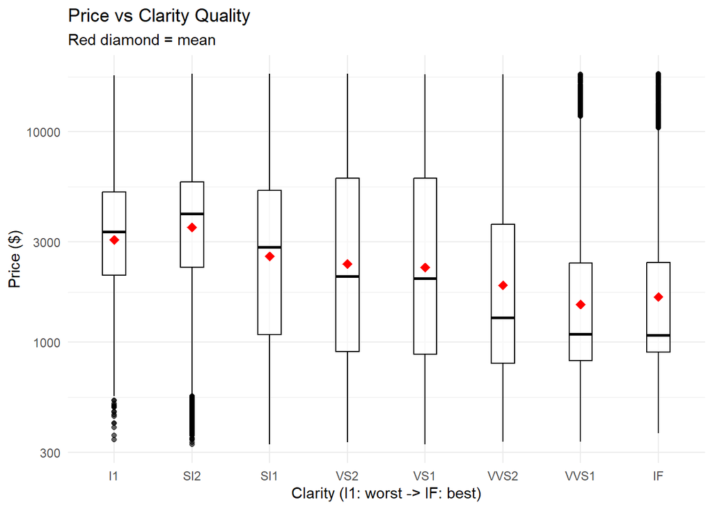

```r
# 3. Price vs Clarity (I1 is worst, IF is best)
ggplot(diamonds, aes(x = clarity, y = price)) +
  geom_boxplot(alpha = 0.6, fill = "white", color = "black", width = 0.3) +
  stat_summary(fun = mean, geom = "point", shape = 18, size = 3, color = "red") +
  scale_y_log10() +
  labs(
    title = "Price vs Clarity Quality",
    subtitle = "Red diamond = mean",
    x = "Clarity (I1: worst -> IF: best)",
    y = "Price ($)"
  ) +
  theme_minimal()
```

From these plots we can clearly observe the **paradox**: - **Color:** diamonds with the worst color (`J`) have a noticeably higher median and mean price compared to diamonds with the best color (`D`). - **Clarity:** diamonds with lower clarity (such as `SI2` or `I1`) tend to cost more on average than diamonds with flawless clarity (`IF` or `VVS1`). - **Cut:** the worst cut (`Fair`) has a higher median price than the best cut (`Ideal`).

### Solving the paradox

To explain why lower-quality diamonds appear more expensive, we look at diamond weight (`carat`):

```r
cor(diamonds$carat, diamonds$price)
```

```
## [1] 0.9215913
```

```r
# Mean carat weight across colors and clarities
diamonds |>
  group_by(color) |>
  summarise(mean_carat = mean(carat))
```

```
## # A tibble: 7 × 2
##   color mean_carat
##   <ord>      <dbl>
## 1 D          0.658
## 2 E          0.658
## 3 F          0.737
## 4 G          0.771
## 5 H          0.912
## 6 I          1.03
## 7 J          1.16
```

```r
diamonds |>
  group_by(clarity) |>
  summarise(mean_carat = mean(carat))
```

```
## # A tibble: 8 × 2
##   clarity mean_carat
##   <ord>        <dbl>
## 1 I1           1.28
## 2 SI2          1.08
## 3 SI1          0.850
## 4 VS2          0.764
## 5 VS1          0.727
## 6 VVS2         0.596
## 7 VVS1         0.503
## 8 IF           0.505
```

The correlation of 0.92 confirms that weight is the primary driver of price. Furthermore, lower-quality diamonds are on average much larger: diamonds with color `J` (worst) weigh 1.16 carats compared to 0.66 carats for color `D` (best). Similarly, clarity `I1` (worst) averages 1.28 carats versus 0.50 carats for `IF` (best). In nature, large crystals are far more likely to contain flaws, so lower-quality diamonds cost more simply because they are much heavier.

#### Multiple Linear Regression

To see how quality really affects price when comparing diamonds of the same weight, we fit a multiple linear regression model. We use a log scale because the relationship between size and price is non-linear: larger diamonds become exponentially more expensive due to rarity, and quality affects price in percentage terms rather than by a fixed dollar amount.

```r
mod_diamonds <- lm(log(price) ~ log(carat) + cut + color + clarity, data = diamonds)
broom::glance(mod_diamonds)
```

```
## # A tibble: 1 × 12
##   r.squared adj.r.squared sigma statistic p.value    df logLik     AIC     BIC
##       <dbl>         <dbl> <dbl>     <dbl>   <dbl> <dbl>  <dbl>   <dbl>   <dbl>
## 1     0.983         0.983 0.134   169326.       0    18 31967. -63893. -63715.
## # ℹ 3 more variables: deviance <dbl>, df.residual <int>, nobs <int>
```

The model explains **98.3%** of the variance in log-price ($R^2 \approx 0.983$). Once we control for carat weight, the paradox is solved: holding size constant, higher quality (better cut, color, and clarity) consistently increases diamond price.

We can see this directly in the plot below. At any fixed carat weight, higher-quality diamonds consistently stay above lower-quality ones:

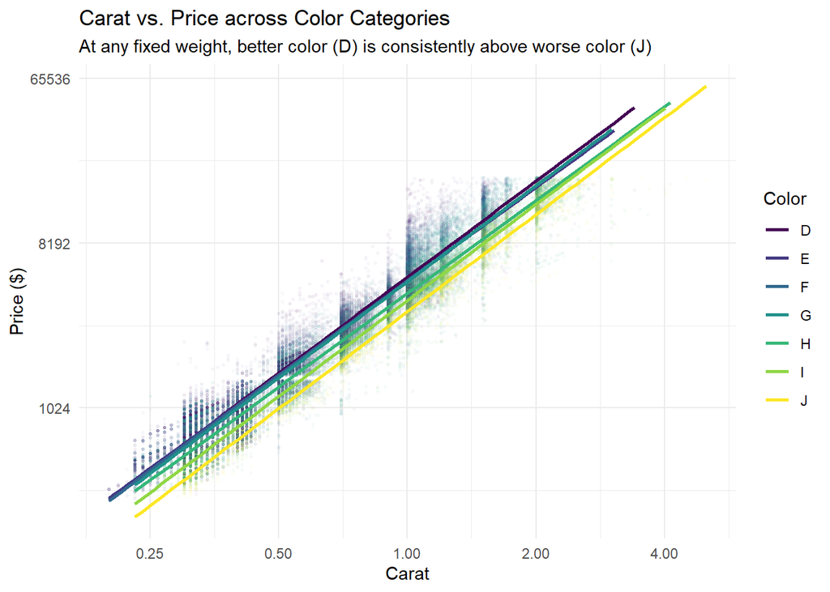

```r
ggplot(diamonds, aes(x = carat, y = price, color = color)) +
  geom_point(alpha = 0.03, size = 0.5) +
  scale_x_continuous(trans = "log2") +
  scale_y_continuous(trans = "log2") +
  geom_smooth(method = "lm", se = FALSE) +
  labs(
    title = "Carat vs. Price across Color Categories",
    subtitle = "At any fixed weight, better color (D) is consistently above worse color (J)",
    x = "Carat",
    y = "Price ($)",
    color = "Color"
  ) +
  theme_minimal()
```